# UpSetR charts

Russ Hyde

2018-09-30

Venn diagrams blow.

Multiset Venn diagrams both blow and suck:

- Don’t make them; and
- Don’t make me interpret them; and
- Don’t try and put them in your presentations because you’ll get lost.

`UpSetR` provides a way to do the multi-set comparison thing without looking horrific.

We sample a few sets from the letters `b-z`:

```r
library("UpSetR")

set.seed(1)

bucket_names <- paste0("set", 1:6)

buckets <- Map(
  function(x){
    bucket_size <- sample(1:25, 1)
    bucket <- sample(letters[-1], bucket_size, replace = FALSE)
    },
  bucket_names
  )
```

```r
lapply(buckets, sort)
```

```
## $set1
## [1] "f" "k" "n" "o" "t" "v" "x"
##
## $set2
##  [1] "c" "d" "f" "h" "i" "j" "k" "m" "n" "o" "q" "r" "s" "w" "y" "z"
##
## $set3
##  [1] "b" "e" "i" "k" "l" "m" "p" "v" "x" "y"
##
## $set4
##  [1] "b" "c" "d" "f" "g" "i" "k" "l" "n" "o" "p" "q" "s" "t" "u" "v" "w"
## [18] "x" "y" "z"
##
## $set5
##  [1] "c" "f" "h" "j" "k" "n" "q" "r" "s" "t" "v" "w" "y"
##
## $set6
##  [1] "b" "c" "d" "e" "f" "g" "i" "j" "k" "l" "m" "n" "p" "q" "r" "s" "t"
## [18] "u" "w" "x" "z"
```

The function `upset` takes a data-frame as input. But I’ve just defined my sets as a list of vectors. To convert these into a data-frame, use `UpSetR::fromList`:

```r
fromList(buckets)
```

```
##    set1 set2 set3 set4 set5 set6
## 1     1    1    1    1    1    1
## 2     1    1    0    1    0    0
## 3     1    0    1    1    1    0
## 4     1    1    0    1    1    1
## 5     1    0    0    1    1    1
## 6     1    0    1    1    0    1
## 7     1    1    0    1    1    1
## 8     0    1    0    1    1    1
## 9     0    1    1    1    1    0
## 10    0    1    0    1    1    1
## 11    0    1    0    0    1    1
## 12    0    1    0    1    1    1
## 13    0    1    0    0    1    1
## 14    0    1    0    0    1    0
## 15    0    1    1    0    0    1
## 16    0    1    0    1    0    1
## 17    0    1    1    1    0    1
## 18    0    1    0    1    0    1
## 19    0    1    0    1    1    1
## 20    0    0    1    1    0    1
## 21    0    0    1    1    0    1
## 22    0    0    1    0    0    1
## 23    0    0    1    1    0    1
## 24    0    0    0    1    0    1
## 25    0    0    0    1    0    1
```

The letter ‘a’ is absent from every one of these sets. you could add a `universe` entry or an `unobserved` entry to the set-list passed to `fromList` if that’s what you’re into.

Otherwise, to generate an upset plot do the following:

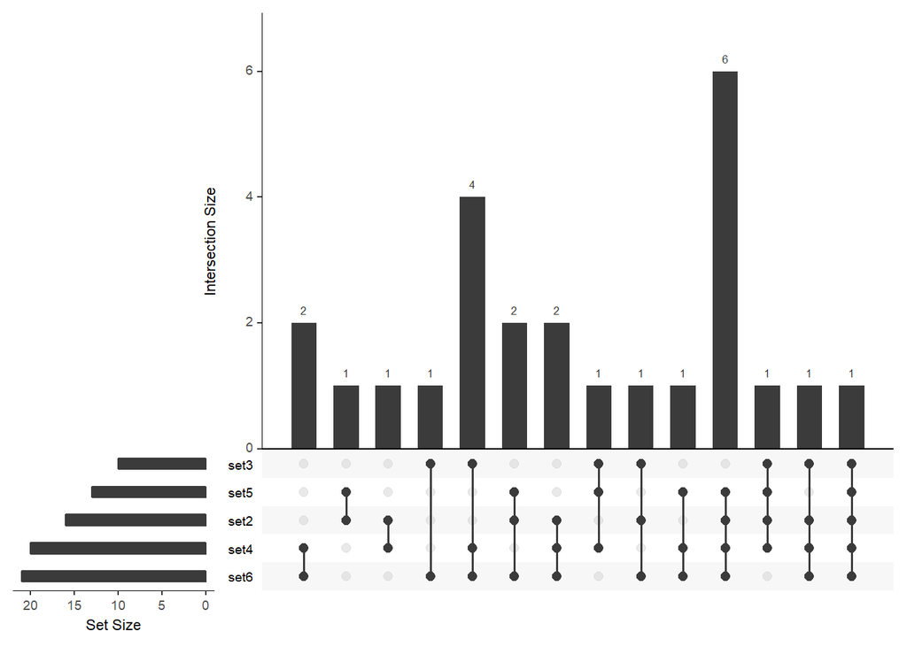

```r
upset(
  fromList(buckets)
  )
```

To ensure that all the sets are displayed in the figure, modify the `nsets` argument: You can order the bars by size (`order.by = "freq"`) or by the number of sets that contributed to the intersection (`order.by = "degree"`) or by both:

```r
# order by freq
upset(
  fromList(buckets), nsets = length(buckets), order.by = "freq"
)
```

[figure not shown]

[figure not shown]

```r
# order by degree and then by freq (not shown)
upset(
  fromList(buckets), order.by = c("freq", "degree"),
  nsets = length(buckets)
  )
```

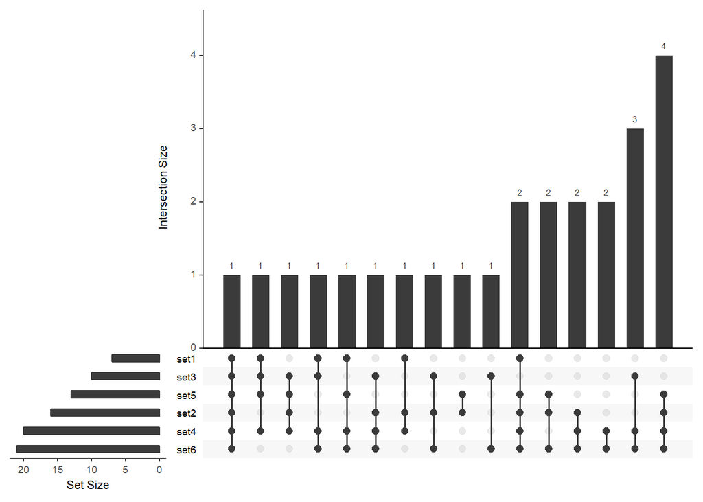

```r
# order by freq and then by degree
upset(
  fromList(buckets), order.by = c("degree", "freq"),
  nsets = length(buckets)
  )
```

I found the latter a bit weird, in that order.by = c(“degree”, “freq”) sorts by increasing frequency, whereas order.by=“freq” sorts by decreasing frequency.